# Wrangling, Exploration, Visualization

Andrea Virgen

# Analysis of Texas Health Indicators

### Introduction

I’m interested to see how and if there are correlations between rates of obesity and sufficient physical activity in regards to life expectancy. I would infer that counties with the highest rates of obesity would have lower life expectancy, but it remains to be seen if higher rates of sufficient exercise compensates for these rates. The first dataset(phys) shows percentage prevalence of each location’s population that achieves a sufficient amount of physical activity - specificity of measurement or sample size is unknown. The second dataset(obesity) shows percentage prevalence of obesity(criteria not given), normalized by age. The final dataset(life) houses life expectancies by county.

```r
library(readr)
library(tidyverse)
library(readxl)

phys <- read_excel("IHME_county_data_LifeExpectancy_Obesity_PhysicalActivity_TEXAS.xls",
    sheet = "Physical Activity")

obesity <- read_excel("IHME_county_data_LifeExpectancy_Obesity_PhysicalActivity_TEXAS.xls",
    sheet = "Obesity")

life <- read_excel("IHME_county_data_LifeExpectancy_Obesity_PhysicalActivity_TEXAS.xls",
    sheet = "Life Expectancy")
```

### Tidying: Reshaping

```r
life %>%
  select(-14:15) %>%
  pivot_longer(-1, names_to="desc", values_to="Life Expectancy") %>%
  rename("Location" = "State/County") %>%
  separate(desc, into = c("desc2", "Year"), sep=", ") %>%
  separate(desc2, into=c("Sex", NA)) %>%
  filter(Sex!="Difference") %>%
  group_by(Location, Sex) %>%
  transmute("Avg Life Expectancy"= sum(`Life Expectancy`)/n()) %>%
  distinct() -> life

phys %>%
  select(1:7)%>%
  pivot_longer(c(2:7), names_to = "desc", values_to= "Percent Active") %>%
  separate(desc, into=c("desc2", "year"), sep=", ") %>%
  separate(desc2, into =c("Sex",NA,NA,NA,NA)) %>%
  separate(year, into="Year") %>%
  rename(Location = "State/County") -> phys

obesity %>%
  select(1:7) %>%
  pivot_longer(c(2:7), names_to = "desc", values_to= "Percent Obese") %>%
  separate(desc, into =c("desc2", "Year"), sep=", ") %>%
  separate(desc2, into=c("Sex", NA, NA)) %>%
  separate(Year, into="Year") %>%
  rename(Location = "State/County") -> obesity
```

### Joining/Merging

```r
inner_join(phys, obesity, by=c("Location", "Sex", "Year")) %>%
  left_join(life, by=c("Location", "Sex")) -> health_indicators
```

Because phys and obesity are the same length, I can perform an inner join without losing any data. My life dataset is averages over a span of 25 years, so I will have repeated numbers for each Location after perfoming a left join to the previously inner-joined dataset.

### Wrangling

```r
health_indicators %>%
  na.omit -> health_indicators

# highest life expectancy for males
health_indicators %>%
  arrange(desc(`Avg Life Expectancy`)) %>%
  select(1:2, 6) %>%
  group_by(Location, Sex) %>%
  filter(Sex=="Male") %>%
  distinct()
```

```
## # A tibble: 256 × 3
## # Groups:   Location, Sex [256]
##    Location   Sex   `Avg Life Expectancy`
##    <chr>      <chr>                 <dbl>
##  1 Collin     Male                   76.5
##  2 Williamson Male                   76.1
##  3 Hidalgo    Male                   75.9
##  4 Fort Bend  Male                   75.9
##  5 Hays       Male                   75.4
##  6 Denton     Male                   75.4
##  7 Bandera    Male                   75.3
##  8 Brazos     Male                   75.1
##  9 Travis     Male                   75.1
## 10 Cameron    Male                   74.9
## # ℹ 246 more rows
```

```r
# highest life expectancy for females
health_indicators %>%
  arrange(desc(`Avg Life Expectancy`)) %>%
  select(1:2, 6) %>%
  group_by(Location, Sex) %>%
  filter(Sex=="Female") %>%
  distinct()
```

```
## # A tibble: 256 × 3
## # Groups:   Location, Sex [256]
##    Location   Sex    `Avg Life Expectancy`
##    <chr>      <chr>                  <dbl>
##  1 Hidalgo    Female                  81.7
##  2 Cameron    Female                  81.3
##  3 Collin     Female                  81.1
##  4 Williamson Female                  81.0
##  5 Webb       Female                  80.9
##  6 Fort Bend  Female                  80.8
##  7 Kerr       Female                  80.8
##  8 Gillespie  Female                  80.8
##  9 Mason      Female                  80.8
## 10 Menard     Female                  80.8
## # ℹ 246 more rows
```

```r
# average obesity rates by year
health_indicators %>%
  filter(Location!=c("United States", "Texas")) %>%
  group_by(Year, Sex) %>%
  summarize(`Overall Average Percent of Population Considered Obese` = sum(`Percent Obese`)/n(), `Overall Average Percent of Population Considered Sufficiently Active` = sum(`Percent Active`)/n())
```

```
## # A tibble: 6 × 4
## # Groups:   Year [3]
##   Year  Sex    Overall Average Percent of Population Co…¹ Overall Average Perc…²
##   <chr> <chr>                                       <dbl>                  <dbl>
## 1 2001  Female                                       33.2                   41.5
## 2 2001  Male                                         29.3                   50.5
## 3 2009  Female                                       39.6                   46.6
## 4 2009  Male                                         36.8                   53.1
## 5 2011  Female                                       40.5                   47.7
## 6 2011  Male                                         38.0                   51.3
## # ℹ abbreviated names:
## #   ¹`Overall Average Percent of Population Considered Obese`,
## #   ²`Overall Average Percent of Population Considered Sufficiently Active`
```

```r
# highest performers above the mean
health_indicators %>%
  group_by(Location) %>%
  filter(`Percent Active` > mean(`Percent Active`)) %>%
  arrange(desc(`Percent Active`))
```

```
## # A tibble: 845 × 6
## # Groups:   Location [256]
##    Location   Sex   Year  `Percent Active` `Percent Obese` `Avg Life Expectancy`
##    <chr>      <chr> <chr>            <dbl>           <dbl>                 <dbl>
##  1 Loving     Male  2009              64.9            34.9                  71.2
##  2 Comal      Male  2009              64.7            34.1                  74.8
##  3 Travis     Male  2001              64.7            20.8                  75.1
##  4 Williamson Male  2001              64.6            23.9                  76.1
##  5 Travis     Male  2009              64.4            28.4                  75.1
##  6 Bell       Male  2001              64.2            25.8                  72.6
##  7 Hays       Male  2009              63.9            33.8                  75.4
##  8 Williamson Male  2009              63.5            32.6                  76.1
##  9 Comal      Male  2011              63.2            35.1                  74.8
## 10 Collin     Male  2001              63.1            25.5                  76.5
## # ℹ 835 more rows
```

```r
# how often does active percent exceed obese percent?
health_indicators %>%
  mutate(`Higher Percent` = ifelse(`Percent Active` > `Percent Obese`, "Active", "Obese")) -> comparison

comparison %>%
  filter(`Higher Percent` == "Obese") %>%
  arrange(desc(`Percent Obese`)) %>%
  str_match_all("20[0-9]{2}") %>%
  unlist() %>%
  table()
```

```
## .
## 2001 2009 2011
##   34   46   49
```

### Visualizing

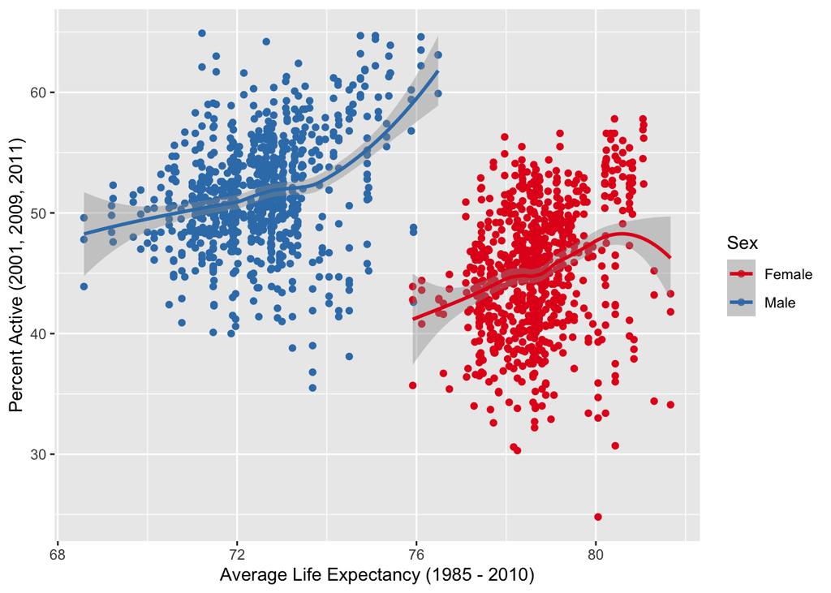

```r
health_indicators %>%
  ggplot(aes(`Avg Life Expectancy`, `Percent Active`, color=Sex)) + geom_point() + scale_color_brewer(palette="Set1") + geom_smooth() + xlab("Average Life Expectancy (1985 - 2010)") + ylab("Percent Active (2001, 2009, 2011)")
```

Here I am examining the correlation between percent of population that is sufficiently active and life expectancy averaged from data points taken in 5 year intervals from 1985 - 2010. A few interesting takeaways: although there is a noticeable correlation between size of active sub-population and the overall life expectancy of males in each county, females greatly exceed male life expectancy with minimal overlap; even though larger sub-populations of males get more physical activity overall, women still have much higher life expectancy across each county; there is also an odd drop off in size of sub-population that gets sufficient physical activity and the average life expectancy in a few counties.

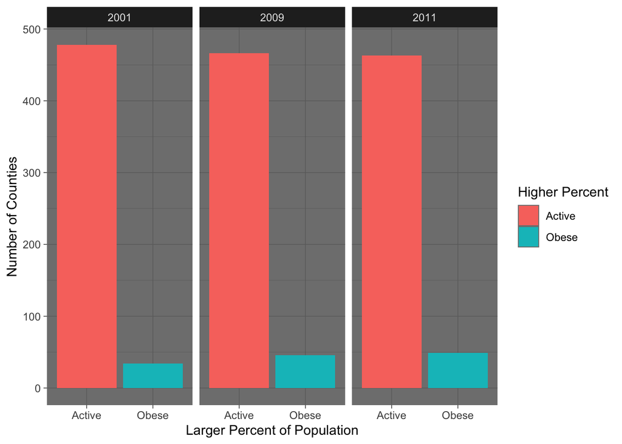

```r
comparison %>%
  ggplot(aes(`Higher Percent`, fill = `Higher Percent`)) + geom_bar() + theme_dark() + ylab("Number of Counties") + xlab("Larger Percent of Population") + facet_grid(~Year)
```

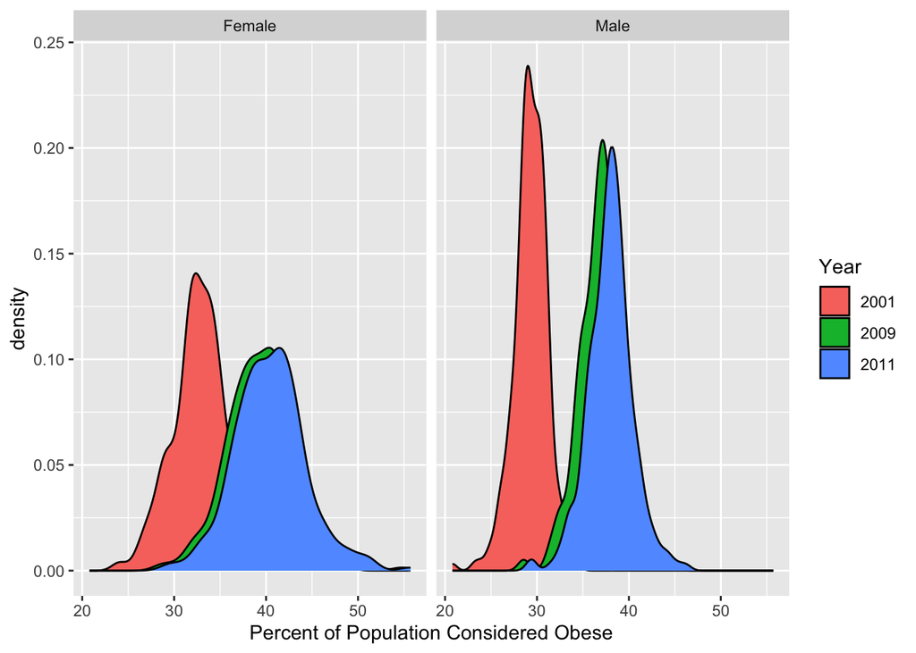

```r
health_indicators %>%
  ggplot(aes(`Percent Obese`, fill = Year)) + geom_density() + xlab("Percent of Population Considered Obese") + facet_grid(~Sex)
```

Each distribution of obesity percentage per county has shifted while maintaining a normal distribution and steady increase over time. Males tend to have more counties with larger obese populations, but females tend to have larger obese populations per county.

### Concluding Remarks

I expected there to be progressively higher rates of obesity, but I didn’t foresee such high rates of individuals getting sufficient physical activity year-over-year. It would be worth doing follow-up research to see if there were confounding factors to these findings: *- Were physical activity rates self-reported?* *- Were the same groups measured each year?* *-Were the sample sizes used unbiased representations of the populations of interest?*